# InPreD_README

### 10.9 I am new to QC and want to use IGV on the TSD

#### 10.9.1 I need to use IGV for QC but I do not have an IGV port.

It is possible to add users so they can get their own IGV port and get an IGV link file created TSOPPI runs. For the IGV link you will need to edit the`config.sh` file in: `/ess/p1150/data/durable/software/pipeline/v004_sequencing_at_OUS_WIP` First open `config.sh` with a text editor and find the following lines: TSOPPI_PORT_NUMBER_LABELS= “Name1 Name2 ect…” and add your name to this list.

[figure not shown]

**Figure 31.** Edit config.sh file to add your name in the TSOPPI_PORT_NUMBER_LABELS variable

**NOTE:** do not delete any previous names from the config file as this will create problems for older files that have been created previously.

To start IGV with your own port you will need to duplicate an other *bat* file from `${DURABLE}/IGV/IGV_2.19.6` or `${DURABLE}/IGV/IGV_2.16.2` Then rename the file duplicated file by changing the port number by the next port number avaliable and the name by your name. E.g.: If the last bat file is `igv_port_60161_Jean-Marc.bat` you can duplicate it and rename it to `igv_port_60162_YourName.bat`.

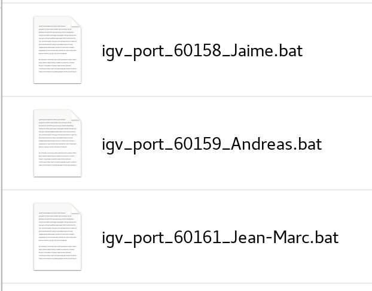

**Figure 32.** Duplicate and rename the .bat file to start IGV with your own port

Then open the new renamed *bat* file with a text editor and change the port number in two places (Line 20 and 22, hilighted in red in the figure below) inside the file, E.g.: if you have assigned the port 60162 to your name, change the port number in the *bat* file to 60162.

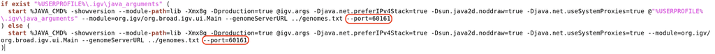

**Figure 33.** Change the port number in the .bat file

#### 10.9.2 I am using IGV for QC for the first time and want to configure it with the correct settings.

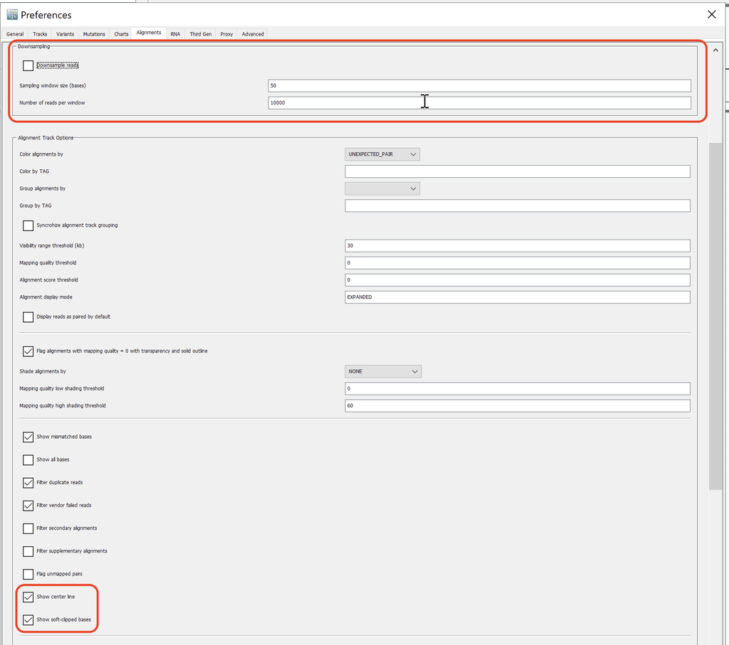

**Figure 34.** Edit IGV settings to show softclip bases, center line and adjust downsampling

### 10.10 Additional information on undescribed variables in the README:

Not all variables are described in this README file as they do not need to be change. Below are the location of folder and files declared by those variables:

```
SCRIPTS_AND_LOGS_FOLDER="${DURABLE}/TSO500_scripts_and_logs/${RUN_ID}"
SAMPLESHEETS_FOLDER="${DURABLE}/TSO500_SampleSheets"
INFO_FILE_NAME="SampleSheet_${RUN_DATE}_info.csv"
INFO_FILE_NAME_TSOPPI="SampleSheet_${RUN_DATE}_info_TSOPPI.csv"
PIPELINE_FOLDER = "${DURABLE}/software/pipeline/v003_upgrading_pronto_to_1.2.0"
```

### 10.11 How can I run TSOPPI, ICNVA and PRONTO without Colossus?

- If Colossus is down and you need to run *TSOPPI* and *ICNVA* you can do it by running the following commands in the terminal.

**Warning:** This method might not work for all the samples as **TSOPPI** and **ICNVA** might need more memory than what is available on the TSD linux machine.

- Open a new terminal, ssh to the hpc and go to:

```bash
cd /ess/p1150/data/durable/software/Ahus_InPreD_toolkit/Run_pipeline_locally
```

- For *TSOPPI*, first generate the *TSOPPI* config file by running the following command:

```bash
python scripts/generate_config_file.py -r ${RUN_ID} -i ${DURABLE}/TSO500_SampleSheets/SampleSheet_${RUN_DATE}_info.csv -s ";" -c 1 -t 2 -u 3 -q 3 > config_${RUN_ID}.sh
```

- Then execute the script execute_TSOPPI_TEMPORARY to get all the commands needed to run TSOPPI for each samples

```bash
bash scripts/get_commands_execute_TSOPPI_locally.sh ./config.sh ${RUN_ID} config_${RUN_ID}.sh
```

- Then run each command one by one for each sample, e.g.:

  ```
  /ess/p1150/data/durable/software/pipeline/v004_sequencing_at_OUS_WIP/scripts/TSOPPI_one_patient.sbatch
  ./config.sh 250606_AAAAAAAA_BBBB_CCCCCCCCCC IPA0123_D01-d01-A01
  /ess/p1150/data/durable/TSO500_analyses/250606_AAAAAAAA_BBBB_CCCCCCCCCC_TSO500_LocalApp_analysis_fromRAW
  0.5 3
  ```

- The same process can be applied to run ICNVA, first get the commands by running for each sample:

```bash
bash scripts/get_commands_execute_icnva_locally.sh ./config.sh ${RUN_ID} ${SAMPLE_ID}
```

**NOTE:** The sample ID need to be manually changed in the command above for each sample, eg: `IPA0123_D01-d01-A01`

- Then the command to run ICNVA will be writen at the end of the output message, e.g.:

  ```
  /ess/p1150/data/durable/software/pipeline/v004_sequencing_at_OUS_WIP/scripts/icnva.sbatch
  config.sh 250606_AAAAAAAA_BBBB_CCCCCCCCCC
  IPA0123_D01-d01-A01
  ```

**NOTE:** ICNVA uses a lot of ressources and there is an important risk that the process will fail.

- Finally run PRONTO using the same command as usual but pointing to a modified script.

```bash
for SAMPLE_ID in ${SAMPLE_IDs[@]}
do
      echo "SAMPLE_ID=${SAMPLE_ID}"

      bash scripts/03_generate_and_archive_pronto_report_collect_data_for_export_locally.sh ${RUN_ID} ${SAMPLE_ID} ${SCRIPTS_AND_LOGS_FOLDER}/02_used_scripts/config_${RUN_ID}.sh \
          > ${SCRIPTS_AND_LOGS_FOLDER}/03_generate_and_archive_pronto_v${PRONTO_VERSION}_report_collect_data_for_export_${SAMPLE_ID}_${RUN_ID}.stdout             \
          2> ${SCRIPTS_AND_LOGS_FOLDER}/03_generate_and_archive_pronto_v${PRONTO_VERSION}_report_collect_data_for_export_${SAMPLE_ID}_${RUN_ID}.stderr

done
```

**NOTE:** If you want to run PRONTO for multiple samples you will need to recreate the “$ARRAY_STRING” array.

### 10.12 I get an error message when I upload the RNA-seq data into FuSViz.

If you get an error mentioning incorrect header or empty value for RNA SV, you need to modify the input table generated during the create fusviz input step.

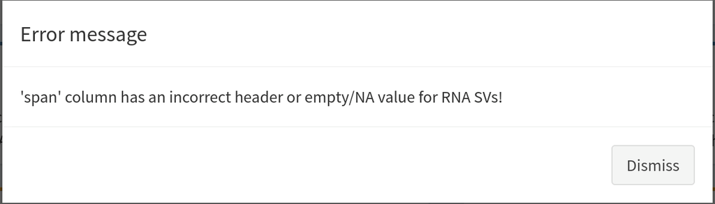

**Figure 35.** Error displayed by FuSviz when loading the input table generated during the create fusviz input step.

This error occurs because the coordinates are associated to two different genes and we need to check manually which gene is the correct one. We will also need to find the strand of the gene. For example in the picture below we can see that for the first fusion two genes are recorded from gene1 and gene2. By comparison the second fusion only has one gene and also has the strand recorded.

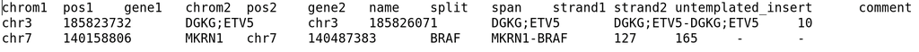

**Figure 36.** FuSViz input table showing the two different cases of fusions with two genes and no strand information and fusions with one gene and strand information.

To fix this error we will first need to find which gene to keep and then manually edit the input table. To find the correct gene we can use the (UCSC genome browser)[https://genome.ucsc.edu/]

- Click on *Genomes* then select *Human GRCh37/hg19*. Now in the search bar you can paste the chromosome and coordinates, e.g.: in our case for gene1 “chr3:185823732”.
- The result of the search will look like the picture below. We can see that ETV5 is the gene overlapping that coordinate so we will keep this one. You should also zoom out to verify that there are no other gene transcripts overlapping.

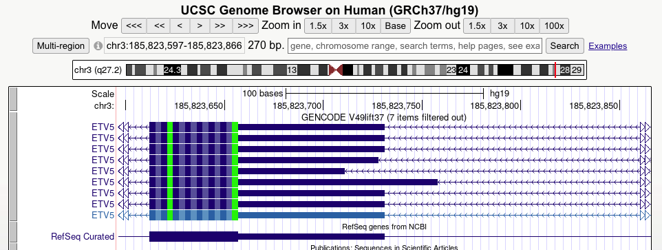

**Figure 37.** Search result in the UCSC genome browser for the coordinates of gene1 of the first fusion.

- In the picture we can also see that the strand is negative and it should be also recorded in the input table.
- Then you can do the same for gene2 and find the correct gene and strand information.
- Finally you need to check the *span*. In this case the span is missing and it is replaced by 0. Also be careful when editing that the tabs are correct and that after the *strand2* column two tabs are present.

**NOTE:** Sometimes a gene name displayed in FuSViz is not matching any names found in the UCSC genome browser. In this case you can use the GeneCards database (https://www.genecards.org/) to find all synonyms of the gene and find the correct one.

### 10.13 How can I automatically create this README file on the TSD for each run?

- To generate this README file on the TSD for a specific run first go to the folder:

```bash
cd  /ess/p1150/data/durable/software/Ahus_InPreD_README/
```

- Then start the singularity container that generate the README file by running the following command, where you have to replace the RUN_ID e.g.: `${RUN_ID}` by the correct run ID.

```bash
singularity run --bind $(pwd)/InPreD_README-main:/app inpred_readme.sif InPreD_pipeline_OUS-Ahus_README.Rmd ${RUN_ID}
```

- The new README file will be generated in: `/ess/p1150/data/durable/software/Ahus_InPreD_README/InPreD_README-main`

**NOTE:** If the Ahus_README github repository has been updated and a new version of the README is availiable you can upload the new version of the file to the TSD and move it to `/ess/p1150/data/durable/software/Ahus_InPreD_README/`

### 10.14 How can I test a new version of PRONTO for validation before production

- You first need to download the updated repository from github
- If needed you can build a tar image that can be then used to create a sif file with apptainer directy on the TSD use the following command locally:

```bash
docker buildx build   --platform linux/amd64   --provenance=false   --output type=docker,dest=./pronto_v3.1.3.tar   -t pronto:3.1.3 .
```

- Upload the new PRONTO repository (respecting naming convention) and the tar image to the TSD.
- On the TSD you can create a new singularity image with the following command:

```bash
apptainer build PRONTO_v3.1.3.sif docker-archive://pronto_v3.1.3.tar
```

**NOTE:** The naming convention of the sif need to be respected for the sif to work.

#### 10.14.1 For testing only:

- Copy the metadata file to the new PRONTO version folder
- Adatpt the `configure_PRONTO.ini`, edit inpred_node and data_path (you might need to edit more parameters in the future)
- Find the testing scripts in the folder: `/ess/p1150/data/durable/software/Ahus_InPreD_toolkit/Test_new_PRONTO_version`
  - copy `config_PRONTO_v2.sh` and `03_generate_and_archive_pronto_report_collect_data_for_export_PRONTO_v2.sh` to `/ess/p1150/data/durable/software/pipeline/v004_sequencing_at_OUS_WIP`
  - copy `generate_report_PRONTO_v2.sbatch` to `/ess/p1150/data/durable/software/pipeline/v004_sequencing_at_OUS_WIP/scripts`
- Those scripts will need to be updated:
  - `config_PRONTO_v2.sh` : update the PRONTO version number and the path test folder output:

  ```bash
  REPORTS_ARCHIVE_FOLDER="${TSO500_ARCHIVE_FOLDER}/TS0500_MTB_report/MTB_report_PRONTO_V2"
  EXPORT_ARCHIVE_FOLDER="${TSD_PREFIX}/TS0500_export_for_interpretation/Test_PRONTO_V2"
  ```

  - `03_generate_and_archive_pronto_report_collect_data_for_export_PRONTO_v2.sh`: update the config file source and the path test folder output:

  ```bash
  source config_PRONTO_v2.sh ${RUN_ID})
  ${SCRIPTS_FOLDER}/generate_report_PRONTO_v2.sbatch
  ```

  - `generate_report_PRONTO_v2.sbatch` : update the config file source (e.g.: source config_PRONTO_v2.sh ${RUN_ID}).
  - Then you can run the new version of PRONTO in parralele with the old version for testing and validation using the following command:

  TEMPORARY section generate reports with PRONTO V2 for testing First source the PRONTO v2 config file:

  ```bash
  source config_PRONTO_v2.sh ${RUN_ID}
  ```

  Then copy the pronto metadata to the PRONTO V2 folder:

  ```bash
  cp -i ${DURABLE}/software/PRONTO/PRONTO-1.2.0/In/InPreD_PRONTO_metadata.txt ${DURABLE}/software/PRONTO/PRONTO-2.1.2/In/InPreD_PRONTO_metadata.txt
  ```

  Then launch pronto V2:

  ```bash
  for SAMPLE_ID in ${SAMPLE_IDs[@]}
  do
        echo "SAMPLE_ID=${SAMPLE_ID}"

        bash 03_generate_and_archive_pronto_report_collect_data_for_export_PRONTO_v2.sh ${RUN_ID} ${SAMPLE_ID} ${SCRIPTS_AND_LOGS_FOLDER}/02_used_scripts/config_${RUN_ID}.sh \
            > ${EXPORT_ARCHIVE_FOLDER}/Logs_outputs/03_generate_and_archive_pronto_v${PRONTO_VERSION}_report_collect_data_for_export_${SAMPLE_ID}_${RUN_ID}.stdout             \
            2> ${EXPORT_ARCHIVE_FOLDER}/Logs_outputs/03_generate_and_archive_pronto_v${PRONTO_VERSION}_report_collect_data_for_export_${SAMPLE_ID}_${RUN_ID}.stderr

  done
  ```

#### 10.14.2 For production:

- Update the version number in `config.sh`
- Copy the metadata file to the new PRONTO version folder
- Adatpt the `configure_PRONTO.ini`, edit `inpred_node` and `data_path` (you might need to edit more parameters in the future)
- For version 3.1.3 we also added the follow line to the `generate_report_PRONTO.sbatch` file to use the template from the folder instead of the one in the container:

  ```bash
  -B ${PRONTO_FOLDER}/In/Template:/pronto/In/Template \
  ```